# Coding Assignment 3

Team 7

Due: 2022-12-09 23:59

A Florida health insurance company wants to predict annual claims for individual clients. The company pulls a random sample of 50 customers. The owner wishes to charge an actuarially fair premium to ensure a normal rate of return. The owner collects all of their current customer’s health care expenses from the last year and compares them with what is known about each customer’s plan.

The data on the 50 customers in the sample is as follows:

- Charges: Total medical expenses for a particular insurance plan (in dollars)
- Age: Age of the primary beneficiary
- BMI: Primary beneficiary’s body mass index (kg/m2)
- Female: Primary beneficiary’s birth sex (0 = Male, 1 = Female)
- Children: Number of children covered by health insurance plan (includes other dependents as well)
- Smoker: Indicator if primary beneficiary is a smoker (0 = non-smoker, 1 = smoker)
- Cities: Dummy variables for each city with the default being Sanford

Answer the following questions using complete sentences and attach all output, plots, etc. within this report.

## Question 1

Randomly select three observations from the sample and exclude from all modeling (i.e. n=47). Provide the summary statistics (min, max, std, mean, median) of the quantitative variables for the 47 observations.

```r
set.seed(123456)
index <- sample(seq_len(nrow(insurancegroup7)), size = 3)

#data set of 47 observations ALL columns
training_set <- insurancegroup7[-index,]

#data set of 3 observations ALL columns
testing_set <- insurancegroup7[index,]

# Summary Statistics
summary(training_set[,c(1:3,5)])
```

```
##     Charges           Age             BMI           Children
##  Min.   : 1147   Min.   :18.00   Min.   :19.95   Min.   :0.000
##  1st Qu.: 4230   1st Qu.:24.00   1st Qu.:28.59   1st Qu.:0.000
##  Median : 9850   Median :36.00   Median :31.82   Median :1.000
##  Mean   :15279   Mean   :37.23   Mean   :32.21   Mean   :1.128
##  3rd Qu.:19963   3rd Qu.:49.50   3rd Qu.:36.62   3rd Qu.:2.000
##  Max.   :58571   Max.   :63.00   Max.   :43.01   Max.   :5.000
```

```r
noquote("Standard deviation for Charges")
```

```
## [1] Standard deviation for Charges
```

```r
sd(training_set$Charges)
```

```
## [1] 14780.4
```

```r
noquote("Standard deviation for Age")
```

```
## [1] Standard deviation for Age
```

```r
sd(training_set$Age)
```

```
## [1] 14.60675
```

```r
noquote("Standard deviation for BMI")
```

```
## [1] Standard deviation for BMI
```

```r
sd(training_set$BMI)
```

```
## [1] 5.214501
```

```r
noquote("Standard deviation for Children")
```

```
## [1] Standard deviation for Children
```

```r
sd(training_set$Children)
```

```
## [1] 1.408314
```

One thing that is obvious here is that our dependent variable is skewed to the right. The mean is about 5.4 thousand dollars higher than the median and the standard deviation is high, and the range is from 1.1k to 59k. We may have outliers in our data.

## Question 2

Provide the correlation between all quantitative variables

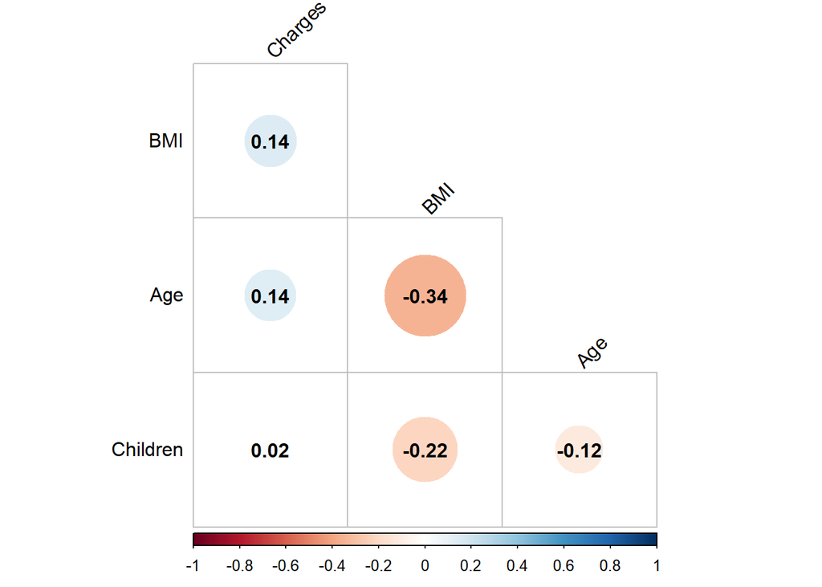

```r
corrplot(cor(training_set[,c(1:3,5)]),
         type = "lower",order = "hclust",
         tl.col = "black",
         tl.srt = 45,
         addCoef.col = "black",
         diag = FALSE,)
```

None of the variables have a high correlation with each other.

## Question 3

Run a regression that includes all independent variables in the data table. Does the model above violate any of the Gauss-Markov assumptions? If so, what are they and what is the solution for correcting?

```r
model_1 <- lm(Charges~., data = training_set)
summary(training_set)
```

```
##     Charges           Age             BMI            Female
##  Min.   : 1147   Min.   :18.00   Min.   :19.95   Min.   :0.000
##  1st Qu.: 4230   1st Qu.:24.00   1st Qu.:28.59   1st Qu.:0.000
##  Median : 9850   Median :36.00   Median :31.82   Median :0.000
##  Mean   :15279   Mean   :37.23   Mean   :32.21   Mean   :0.383
##  3rd Qu.:19963   3rd Qu.:49.50   3rd Qu.:36.62   3rd Qu.:1.000
##  Max.   :58571   Max.   :63.00   Max.   :43.01   Max.   :1.000
##     Children         Smoker      WinterSprings      WinterPark
##  Min.   :0.000   Min.   :0.000   Min.   :0.0000   Min.   :0.0000
##  1st Qu.:0.000   1st Qu.:0.000   1st Qu.:0.0000   1st Qu.:0.0000
##  Median :1.000   Median :0.000   Median :0.0000   Median :0.0000
##  Mean   :1.128   Mean   :0.234   Mean   :0.2766   Mean   :0.2128
##  3rd Qu.:2.000   3rd Qu.:0.000   3rd Qu.:1.0000   3rd Qu.:0.0000
##  Max.   :5.000   Max.   :1.000   Max.   :1.0000   Max.   :1.0000
##      Oviedo
##  Min.   :0.0000
##  1st Qu.:0.0000
##  Median :0.0000
##  Mean   :0.2766
##  3rd Qu.:1.0000
##  Max.   :1.0000
```

```r
summary(model_1)
```

```
##
## Call:
## lm(formula = Charges ~ ., data = training_set)
##
## Residuals:
##      Min       1Q   Median       3Q      Max
## -15794.7  -2524.1   -531.9   1738.8  16107.4
##
## Coefficients:
##                Estimate Std. Error t value Pr(>|t|)
## (Intercept)   -17938.11    7010.07  -2.559  0.01461 *
## Age              246.84      60.87   4.055  0.00024 ***
## BMI              410.24     184.85   2.219  0.03250 *
## Female          1687.79    1951.39   0.865  0.39251
## Children        1295.75     593.12   2.185  0.03515 *
## Smoker         29982.63    2002.76  14.971  < 2e-16 ***
## WinterSprings   4155.17    2387.02   1.741  0.08982 .
## WinterPark      1140.84    2833.12   0.403  0.68944
## Oviedo          1063.18    2460.54   0.432  0.66812
## ---
## Signif. codes:  0 '***' 0.001 '**' 0.01 '*' 0.05 '.' 0.1 ' ' 1
##
## Residual standard error: 5259 on 38 degrees of freedom
## Multiple R-squared:  0.8954, Adjusted R-squared:  0.8734
## F-statistic: 40.66 on 8 and 38 DF,  p-value: 2.643e-16
```

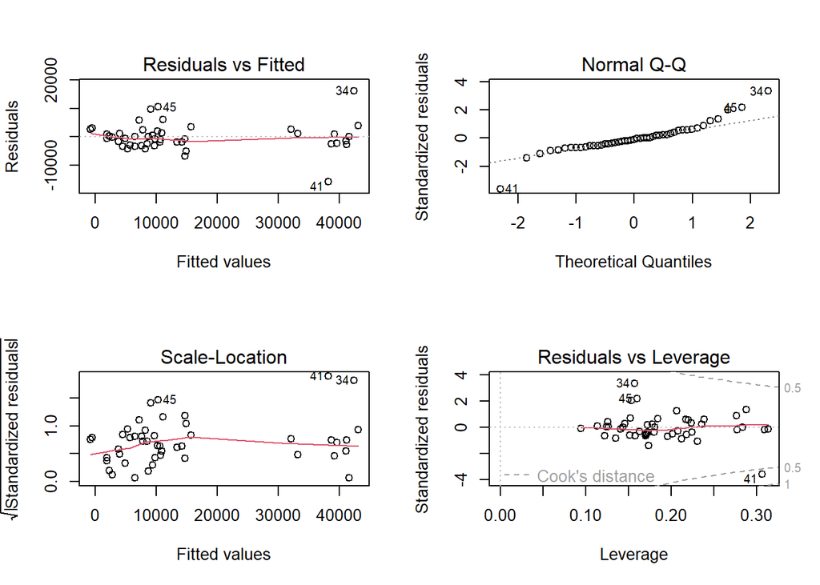

```r
par(mfrow=c(2,2))

##Analyze plot output for assumption violations and provide solutions
##Professor said Residuals vs Fitted violates non-linear
##Normal Q-Q is a violation of #6
plot(model_1)
```

Looking at the residuals vs. fitted plot, there appears to be a violation of Gauss-Markov Assumption #3, specification bias. By using the incorrect functional form “misspecification” occurs, assuming it is a linear function when it’s actually non-linear. The solution is to transform the data using a log or quadratic function.

The Normal QQ plot has a normal flatness, does not form a 45-degree angle, exhibits a heavy tailed distribution, and the dependent variable is not normally distributed. This is a violation of the Gauss-Markov Assumption #6, the error is not normally distributed. A study conducted by Ward et al. found that “health care expenditures are higher for people with excess weight across a wide range of ages and BMI levels, with especially high costs for people with severe obesity.” (Ward et al., 2021) Because it is assumed that the rate of increase in charges related to an increase in BMI is not consistent, one solution is to take the log of charges and the log of BMI creating a normal distribution, bringing outliers closer to other charges. Another solution is to take the log of age, as the rate of increase in charges related to age may not be consistent. We looked at several transformations to determine the best model.

## Question 4

Implement the solutions from question 3, such as data transformation, along with any other changes you wish. Use the sample data and run a new regression. How have the fit measures changed? How have the signs and significance of the coefficients changed?

```r
par(mfrow=c(2,2))

#base model
model_1 <- lm(Charges~., data = training_set[,c(1:9)])
summary(model_1)
```

```
##
## Call:
## lm(formula = Charges ~ ., data = training_set[, c(1:9)])
##
## Residuals:
##      Min       1Q   Median       3Q      Max
## -15794.7  -2524.1   -531.9   1738.8  16107.4
##
## Coefficients:
##                Estimate Std. Error t value Pr(>|t|)
## (Intercept)   -17938.11    7010.07  -2.559  0.01461 *
## Age              246.84      60.87   4.055  0.00024 ***
## BMI              410.24     184.85   2.219  0.03250 *
## Female          1687.79    1951.39   0.865  0.39251
## Children        1295.75     593.12   2.185  0.03515 *
## Smoker         29982.63    2002.76  14.971  < 2e-16 ***
## WinterSprings   4155.17    2387.02   1.741  0.08982 .
## WinterPark      1140.84    2833.12   0.403  0.68944
## Oviedo          1063.18    2460.54   0.432  0.66812
## ---
## Signif. codes:  0 '***' 0.001 '**' 0.01 '*' 0.05 '.' 0.1 ' ' 1
##
## Residual standard error: 5259 on 38 degrees of freedom
## Multiple R-squared:  0.8954, Adjusted R-squared:  0.8734
## F-statistic: 40.66 on 8 and 38 DF,  p-value: 2.643e-16
```

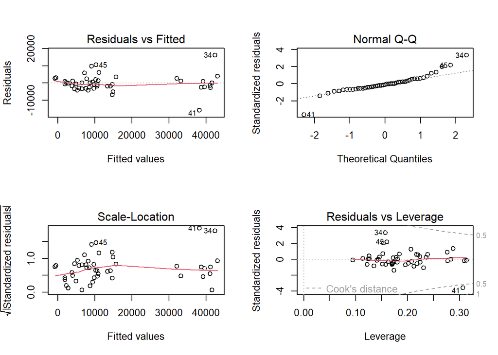

```r
plot(model_1)
```

```r
#Fix Charges' distribution by using log
training_set$lnCharges <- log(training_set$Charges)
hist(training_set$Charges)
hist(training_set$lnCharges)

training_set$lnAge <- log(training_set$Age)
training_set$AgeSquared <- training_set$Age^2

training_set$BMISquared <-training_set$BMI^2
training_set$lnBMI <- log(training_set$BMI)


#Model of Log of Charges, Age, BMI, Children + dummies
model_lnCharges <- lm(lnCharges~., data = training_set[,c(10,2:9)])
summary(model_lnCharges)
```

```
##
## Call:
## lm(formula = lnCharges ~ ., data = training_set[, c(10, 2:9)])
##
## Residuals:
##     Min      1Q  Median      3Q     Max
## -1.0332 -0.1996 -0.0794  0.1301  1.1600
##
## Coefficients:
##                Estimate Std. Error t value Pr(>|t|)
## (Intercept)    6.273504   0.600528  10.447 1.00e-12 ***
## Age            0.038188   0.005214   7.324 9.01e-09 ***
## BMI            0.020147   0.015835   1.272 0.210999
## Female         0.094923   0.167169   0.568 0.573491
## Children       0.207977   0.050810   4.093 0.000214 ***
## Smoker         1.809675   0.171570  10.548 7.60e-13 ***
## WinterSprings  0.426946   0.204488   2.088 0.043565 *
## WinterPark    -0.145869   0.242704  -0.601 0.551396
## Oviedo         0.010156   0.210786   0.048 0.961824
## ---
## Signif. codes:  0 '***' 0.001 '**' 0.01 '*' 0.05 '.' 0.1 ' ' 1
##
## Residual standard error: 0.4506 on 38 degrees of freedom
## Multiple R-squared:  0.8578, Adjusted R-squared:  0.8278
## F-statistic: 28.65 on 8 and 38 DF,  p-value: 8.028e-14
```

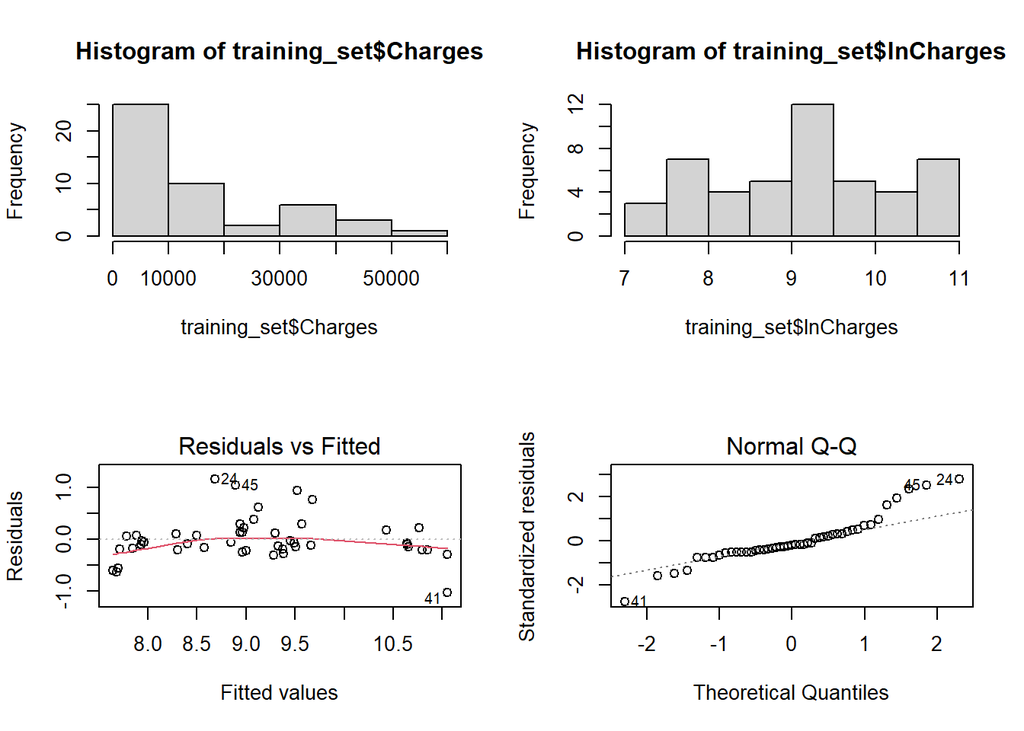

```r
plot(model_lnCharges)
```

```r
#Model of lnCharges, lnAge, BMI, Children + dummies
model_lnAge <- lm(lnCharges~., data = training_set[,c(10,11,3:9)])
summary(model_lnAge)
```

```
##
## Call:
## lm(formula = lnCharges ~ ., data = training_set[, c(10, 11, 3:9)])
##
## Residuals:
##      Min       1Q   Median       3Q      Max
## -1.00385 -0.23150 -0.07839  0.10633  1.11726
##
## Coefficients:
##               Estimate Std. Error t value Pr(>|t|)
## (Intercept)    3.16489    0.94783   3.339 0.001892 **
## lnAge          1.31889    0.18359   7.184 1.39e-08 ***
## BMI            0.01601    0.01579   1.014 0.317038
## Female         0.09853    0.16901   0.583 0.563326
## Children       0.18337    0.05072   3.616 0.000867 ***
## Smoker         1.81037    0.17352  10.433 1.04e-12 ***
## WinterSprings  0.41757    0.20710   2.016 0.050881 .
## WinterPark    -0.06576    0.24255  -0.271 0.787770
## Oviedo         0.04787    0.21204   0.226 0.822597
## ---
## Signif. codes:  0 '***' 0.001 '**' 0.01 '*' 0.05 '.' 0.1 ' ' 1
##
## Residual standard error: 0.4556 on 38 degrees of freedom
## Multiple R-squared:  0.8546, Adjusted R-squared:  0.8239
## F-statistic: 27.91 on 8 and 38 DF,  p-value: 1.216e-13
```

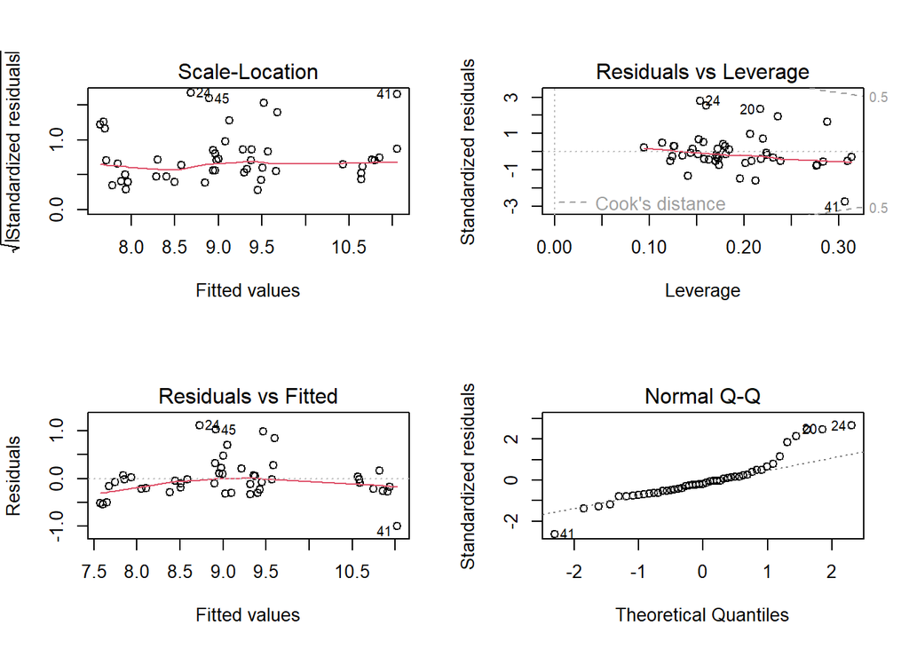

```r
plot(model_lnAge)
```

```r
#Model of lnCharges, Age, Age^2 BMI, Children + dummies
model_AgeSquared <- lm(lnCharges~., data = training_set[,c(10,2:9,12)])
summary(model_AgeSquared)
```

```
##
## Call:
## lm(formula = lnCharges ~ ., data = training_set[, c(10, 2:9,
##     12)])
##
## Residuals:
##      Min       1Q   Median       3Q      Max
## -1.03270 -0.20040 -0.07436  0.12699  1.15954
##
## Coefficients:
##                 Estimate Std. Error t value Pr(>|t|)
## (Intercept)    6.240e+00  7.699e-01   8.105 1.01e-09 ***
## Age            4.066e-02  3.502e-02   1.161 0.253116
## BMI            1.995e-02  1.629e-02   1.224 0.228607
## Female         9.419e-02  1.697e-01   0.555 0.582227
## Children       2.066e-01  5.485e-02   3.767 0.000575 ***
## Smoker         1.810e+00  1.739e-01  10.409 1.52e-12 ***
## WinterSprings  4.264e-01  2.074e-01   2.056 0.046868 *
## WinterPark    -1.419e-01  2.521e-01  -0.563 0.576820
## Oviedo         1.195e-02  2.151e-01   0.056 0.956006
## AgeSquared    -3.217e-05  4.505e-04  -0.071 0.943456
## ---
## Signif. codes:  0 '***' 0.001 '**' 0.01 '*' 0.05 '.' 0.1 ' ' 1
##
## Residual standard error: 0.4566 on 37 degrees of freedom
## Multiple R-squared:  0.8578, Adjusted R-squared:  0.8232
## F-statistic:  24.8 on 9 and 37 DF,  p-value: 4.474e-13
```

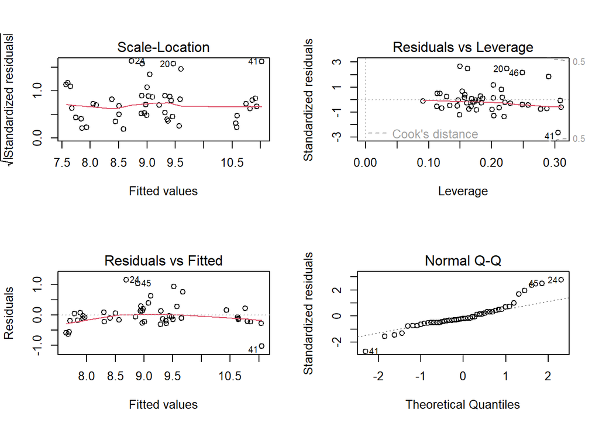

```r
plot(model_AgeSquared)
```

```r
#Model of lnCharges, Age, lnBMI, Children + dummies
model_lnBMI <- lm(lnCharges~., data = training_set[,c(10,2,14,3:9)])
summary(model_lnBMI)
```

```
##
## Call:
## lm(formula = lnCharges ~ ., data = training_set[, c(10, 2, 14,
##     3:9)])
##
## Residuals:
##      Min       1Q   Median       3Q      Max
## -0.66379 -0.22276 -0.05265  0.05232  0.98236
##
## Coefficients:
##                 Estimate Std. Error t value Pr(>|t|)
## (Intercept)   -23.134766   8.335679  -2.775 0.008596 **
## Age             0.038829   0.004572   8.492 3.24e-10 ***
## lnBMI          12.205941   3.452835   3.535 0.001115 **
## BMI            -0.379038   0.113771  -3.332 0.001967 **
## Female          0.059153   0.146822   0.403 0.689348
## Children        0.183084   0.045074   4.062 0.000243 ***
## Smoker          1.785133   0.150490  11.862 3.59e-14 ***
## WinterSprings   0.535520   0.181786   2.946 0.005543 **
## WinterPark      0.004097   0.216848   0.019 0.985027
## Oviedo          0.054758   0.185122   0.296 0.769043
## ---
## Signif. codes:  0 '***' 0.001 '**' 0.01 '*' 0.05 '.' 0.1 ' ' 1
##
## Residual standard error: 0.3948 on 37 degrees of freedom
## Multiple R-squared:  0.8937, Adjusted R-squared:  0.8678
## F-statistic: 34.56 on 9 and 37 DF,  p-value: 2.358e-15
```

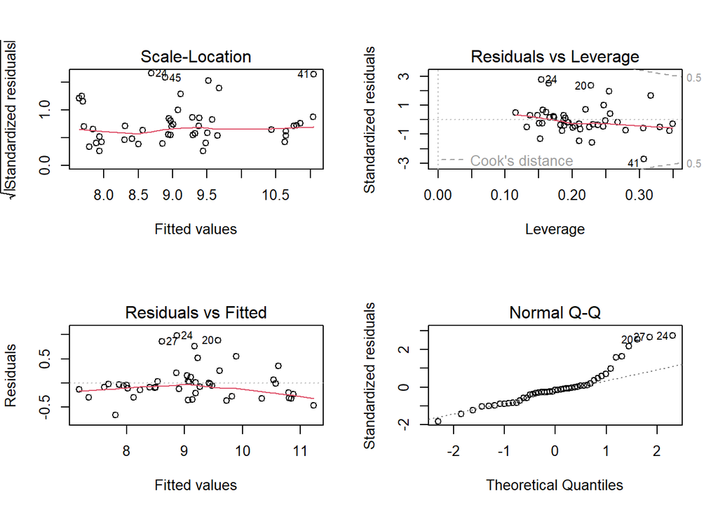

```r
plot(model_lnBMI)
```

```r
#Model of lnCharges, Age, BMI, BMI^2, Children + dummies
model_BMISquared <- lm(lnCharges~., data = training_set[,c(10,2:9,13)])
summary(model_BMISquared)
```

```
##
## Call:
## lm(formula = lnCharges ~ ., data = training_set[, c(10, 2:9,
##     13)])
##
## Residuals:
##      Min       1Q   Median       3Q      Max
## -0.70061 -0.21938 -0.04783  0.05487  0.95111
##
## Coefficients:
##                Estimate Std. Error t value Pr(>|t|)
## (Intercept)   -0.369043   1.855096  -0.199 0.843403
## Age            0.038391   0.004505   8.521 2.97e-10 ***
## BMI            0.454901   0.117371   3.876 0.000420 ***
## Female         0.060818   0.144716   0.420 0.676726
## Children       0.182886   0.044411   4.118 0.000206 ***
## Smoker         1.748304   0.149140  11.723 5.08e-14 ***
## WinterSprings  0.540864   0.179290   3.017 0.004603 **
## WinterPark     0.031975   0.215040   0.149 0.882605
## Oviedo         0.055217   0.182511   0.303 0.763935
## BMISquared    -0.006949   0.001863  -3.730 0.000641 ***
## ---
## Signif. codes:  0 '***' 0.001 '**' 0.01 '*' 0.05 '.' 0.1 ' ' 1
##
## Residual standard error: 0.3893 on 37 degrees of freedom
## Multiple R-squared:  0.8966, Adjusted R-squared:  0.8715
## F-statistic: 35.66 on 9 and 37 DF,  p-value: 1.416e-15
```

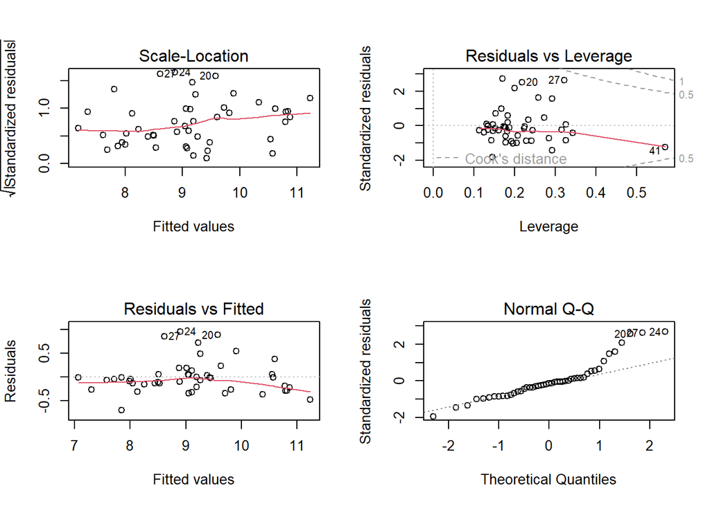

```r
plot(model_BMISquared)
```

```r
#Model of lnCharges, lnAge, lnBMI, Children + dummies
model_lnAll <- lm(lnCharges~., data = training_set[,c(10,11,14,4:9)])
summary(model_lnAll)
```

```
##
## Call:
## lm(formula = lnCharges ~ ., data = training_set[, c(10, 11, 14,
##     4:9)])
##
## Residuals:
##      Min       1Q   Median       3Q      Max
## -0.92090 -0.21842 -0.07778  0.09491  1.11888
##
## Coefficients:
##               Estimate Std. Error t value Pr(>|t|)
## (Intercept)    1.38265    1.95349   0.708 0.483399
## lnAge          1.34366    0.18152   7.402 7.07e-09 ***
## lnBMI          0.64283    0.47345   1.358 0.182550
## Female         0.07902    0.16755   0.472 0.639906
## Children       0.18670    0.04988   3.743 0.000601 ***
## Smoker         1.80718    0.17177  10.521 8.17e-13 ***
## WinterSprings  0.41562    0.20448   2.033 0.049129 *
## WinterPark    -0.08789    0.23747  -0.370 0.713370
## Oviedo         0.03600    0.20939   0.172 0.864419
## ---
## Signif. codes:  0 '***' 0.001 '**' 0.01 '*' 0.05 '.' 0.1 ' ' 1
##
## Residual standard error: 0.4509 on 38 degrees of freedom
## Multiple R-squared:  0.8575, Adjusted R-squared:  0.8275
## F-statistic: 28.59 on 8 and 38 DF,  p-value: 8.287e-14
```

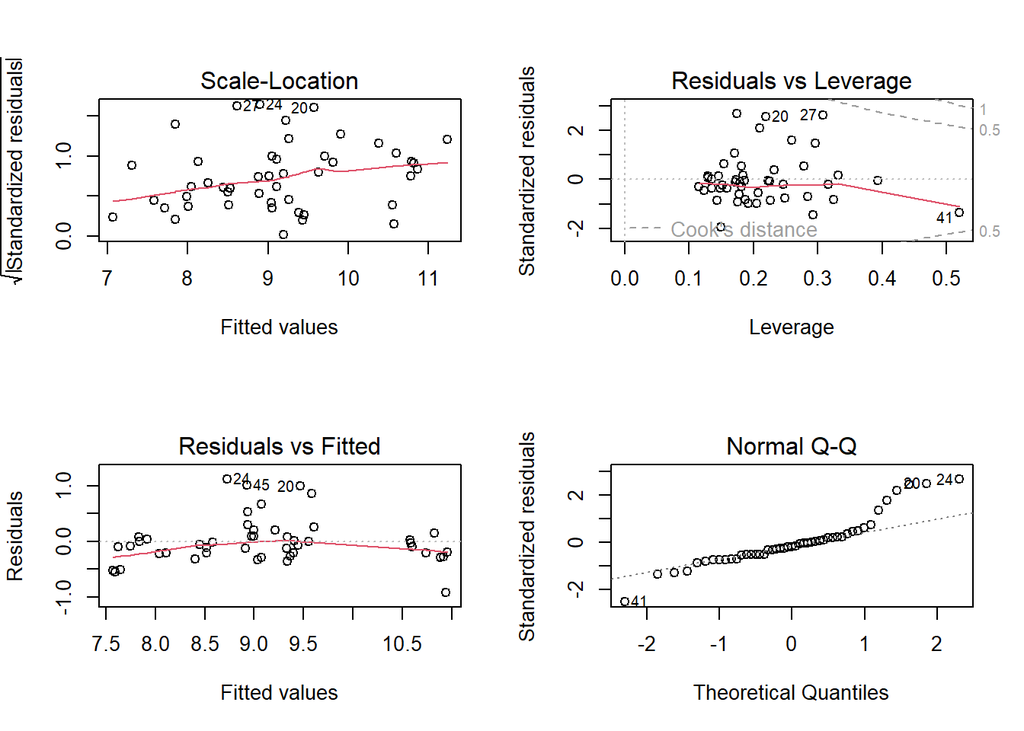

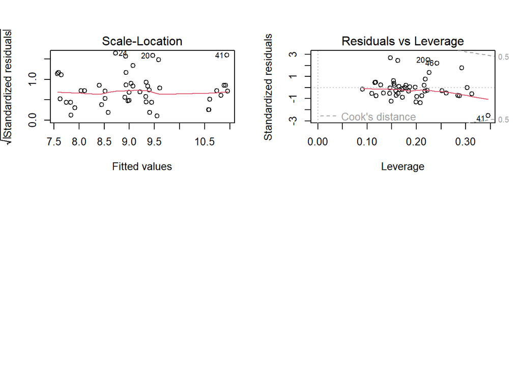

```r
plot(model_lnAll)
```

Base Model: Age, BMI, Children, and Smoker all test significant. R2 is 90%, and the residual standard error is 5259. The dummy variables (cities, Female) do not test significant. The variables that tested significant all have a direct relationship with the dependent variable (Charges).

lnAge Model: By taking the log of Charges and Age, Age, Children, and Smoker test significant, BMI does not test significant. R2 for this model is 86% and Winter Park is negative. The residual standard error is 0.4556.

lnBMI: By taking the log of Charges and Age, Age, Children, BMI, Log BMI, Smoker, and Winter Springs all test significant. BMI changed sign. R2 for this model is 90%. The residual standard error is 0.3948.

BMISquared: By taking the log of Charges and BMI Squared, Age, Children, BMI, BMI Squared, Smoker, and Winter Springs all test significant. BMI Squared changed sign. R2 for this model is 90%. The residual standard error is 0.3893.

## Question 5

#Use the 3 withheld observations and calculate the performance measures for your best two models. Which is the better model? (remember that “better” depends on whether your outlook is short or long run)

```r
#Danny
testing_set$lnCharges <- log(testing_set$Charges)
testing_set$lnAge <- log(testing_set$Age)
testing_set$AgeSquared <- testing_set$Age^2

testing_set$BMISquared <- testing_set$BMI^2
testing_set$lnBMI <- log(testing_set$BMI)

testing_set$base_model_pred <- predict(model_1, newdata = testing_set)

testing_set$model_lnAge_pred <- predict(model_lnAge, newdata = testing_set) %>% exp()

testing_set$model_lnBMI_pred <- predict(model_lnBMI, newdata = testing_set) %>% exp()

testing_set$model_AgeSquared_pred <- predict(model_AgeSquared,newdata = testing_set) %>% exp()

testing_set$model_BMISquared_pred <- predict(model_BMISquared,newdata = testing_set) %>% exp()

testing_set$model_lnAll_pred <- predict(model_lnAll,newdata = testing_set) %>% exp()



testing_set$error_bm <- testing_set$base_model_pred - testing_set$Charges

testing_set$error_1 <- testing_set$model_lnAge_pred - testing_set$Charges

testing_set$error_2 <- testing_set$model_lnBMI_pred - testing_set$Charges

testing_set$error_3 <- testing_set$model_AgeSquared_pred - testing_set$Charges

testing_set$error_4 <- testing_set$model_BMISquared_pred - testing_set$Charges

testing_set$error_5 <- testing_set$model_lnAll_pred - testing_set$Charges

# No Transformations
mean(testing_set$error_bm)
```

```
## [1] 6039.355
```

```r
# Log of Charges and Log of Age
mean(testing_set$error_1)
```

```
## [1] 14770.93
```

```r
#Log of Charges and Log of BMI
mean(testing_set$error_2)
```

```
## [1] 23774.04
```

```r
#Log of Charges, Age, Age^2
mean(testing_set$error_3)
```

```
## [1] 16800.6
```

```r
#Log of Charges, BMI, BMI^2
mean(testing_set$error_4)
```

```
## [1] 22159.62
```

```r
#Log of Charges, Log of Age, Log of BMI
mean(testing_set$error_5)
```

```
## [1] 15173.3
```

```r
mae <- function(error_vector){
  error_vector %>%
  abs() %>%
  mean()
}

# No Transformations
mae(testing_set$error_bm)
```

```
## [1] 6039.355
```

```r
# Log of Charges and Log of Age
mae(testing_set$error_1)
```

```
## [1] 15402.4
```

```r
#Log of Charges and Log of BMI
mae(testing_set$error_2)
```

```
## [1] 24448.5
```

```r
#Log of Charges, Age, Age^2
mae(testing_set$error_3)
```

```
## [1] 17434.38
```

```r
#Log of Charges, BMI, BMI^2
mae(testing_set$error_4)
```

```
## [1] 22757.26
```

```r
#Log of Charges, Log of Age, Log of BMI
mae(testing_set$error_5)
```

```
## [1] 15626.1
```

```r
rmse <- function(error_vector){
   error_vector^2 %>%
  mean() %>%
  sqrt()

}

# No Transformations
rmse(testing_set$error_bm)
```

```
## [1] 8724.774
```

```r
# Log of Charges and Log of Age
rmse(testing_set$error_1)
```

```
## [1] 26053.55
```

```r
#Log of Charges and Log of BMI
rmse(testing_set$error_2)
```

```
## [1] 41682.82
```

```r
#Log of Charges, Age, Age^2
rmse(testing_set$error_3)
```

```
## [1] 29443.97
```

```r
#Log of Charges, BMI, BMI^2
rmse(testing_set$error_4)
```

```
## [1] 38778.33
```

```r
#Log of Charges, Log of Age, Log of BMI
rmse(testing_set$error_5)
```

```
## [1] 26593.68
```

```r
mape <- function(error_vector, actual_vector){
  (error_vector/actual_vector) %>%
    abs() %>%
    mean()
}

# No Transformations
mape(testing_set$error_bm, testing_set$Charges)
```

```
## [1] 0.4551515
```

```r
# Log of Charges and Log of Age
mape(testing_set$error_1, testing_set$Charges)
```

```
## [1] 0.609521
```

```r
#Log of Charges and Log of BMI
mape(testing_set$error_2, testing_set$Charges)
```

```
## [1] 0.9434627
```

```r
#Log of Charges, Age, Age^2
mape(testing_set$error_3, testing_set$Charges)
```

```
## [1] 0.7158938
```

```r
#Log of Charges, BMI, BMI^2
mape(testing_set$error_4, testing_set$Charges)
```

```
## [1] 0.8887885
```

```r
#Log of Charges, Log of Age, Log of BMI
mape(testing_set$error_5, testing_set$Charges)
```

```
## [1] 0.6110568
```

After care full studying the BIAS, MAE, RMSE, and MAPE, we have concluded that the best fit model is the base model. With a 90% fit model and the smallest BIAS, MAE, RMSE, and MAPE, out of all the models, the base model will give us the best results. To better protect the model against large forecasting errors, we looked at the RMSE, and our model scored better on the RMSE than any of the other models. This means that whether its long run or short run, our base model will be a better model than any of the other models.